# Supplementary Information

Who Will Conduct Science? Researchers’ Expectations of AI Capabilities and the Future of Scientific Work (Preprint)

Balazs Aczel, Dominik Dianovics, Peter Szecsi, Barnabas Szaszi

24 November 2026

This document includes the saved tables and all figures. Figures and tables are included from their saved files.

# Invitation email

Dear ${m://FirstName},

I’m Balazs Aczel, and I lead the Metascience Lab at Eotvos Lorand University in Budapest, Hungary.

My colleagues and I are preparing a policy report on how much independence AI should have in scientific research. It would be really helpful for us if you could share your views on how AI is changing research in your field and what it might mean for your own work.

Would you be willing to share your views by completing a short survey? It takes less than 5 minutes, and we welcome responses from researchers across all disciplines, regardless of their experience with AI.

Follow this link to the Survey: ${l://SurveyLink?d=Take the survey}

Or copy and paste the URL below into your internet browser: ${l://SurveyURL}

Thank you in advance for your time and contribution!

Best regards, Prof. Balazs Aczel, Dsc, PhD Eotvos Lorand University, Hungary Faculty of Education and Psychology Budapest, Kazinczy u. 23-27., H-1075 Hungary Tel.: +36 1 461 4500/3464

contact: decisionlab@ppk.elte.hu

You can independently verify this invitation on our university’s website, where we have published information about the study: https://metasciencelab.elte.hu/our-projects/

This invitation was sent through our university’s Qualtrics survey platform. You can verify our institutional affiliation through the ELTE Faculty of Education and Psychology website.

Disclaimer: We found your email address from your ORCID profile. Ethical approval 0602/2026 was issued by the Research Ethics Committee of the Faculty of Education and Psychology of Eötvös Loránd University, Hungary.

If you don’t want to be contacted for our later studies, you can unsubscribe here: ${l://OptOutLink?d=Click here to unsubscribe}

# Tables

## Variables

Table S2. Variables

[output not shown]

*Note.* Variables related to AI can be found in the manuscript.

# Figures

## Response and exclusions

The flow of responses from email invitation to the analysed sample

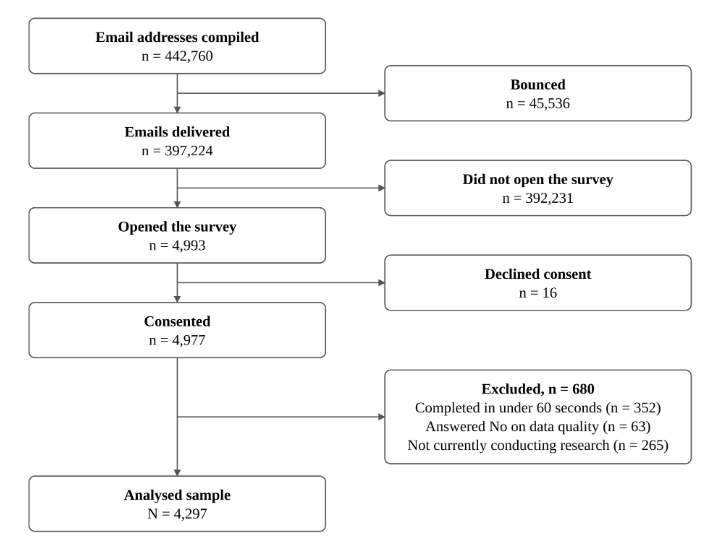

S1

## Respondents by country

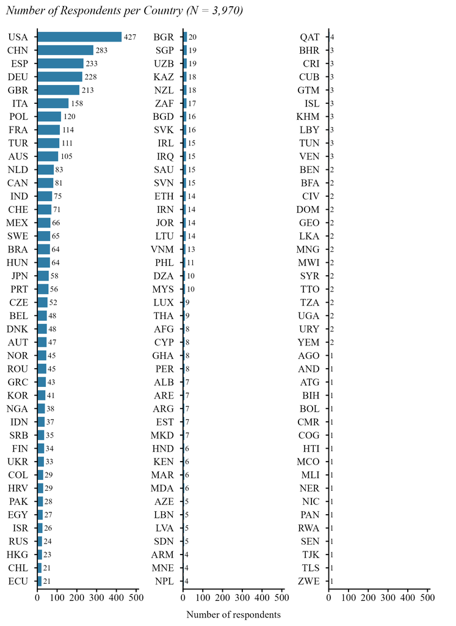

S2

## Geographical distribution

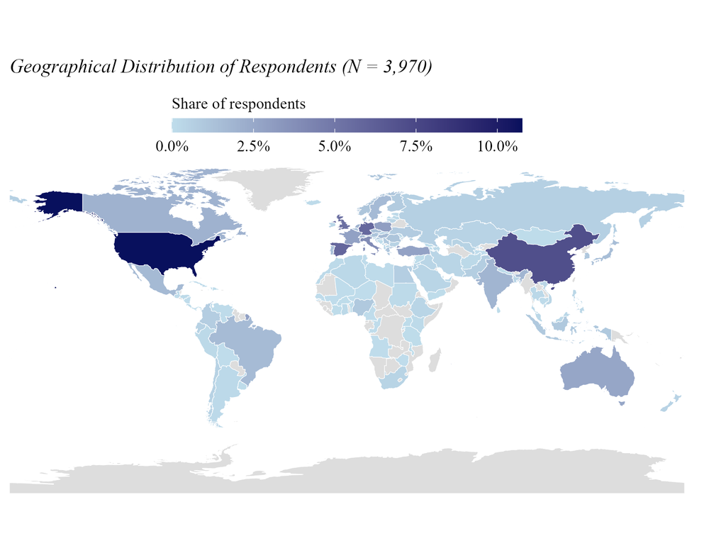

S3

## Disciplines within social sciences

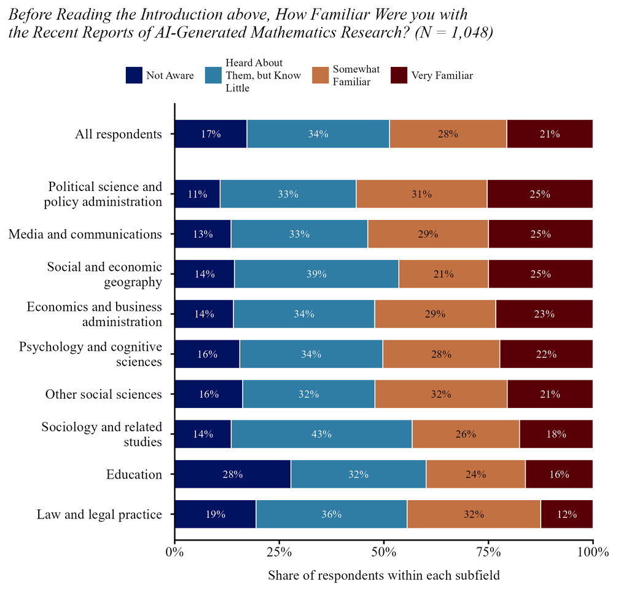

S4

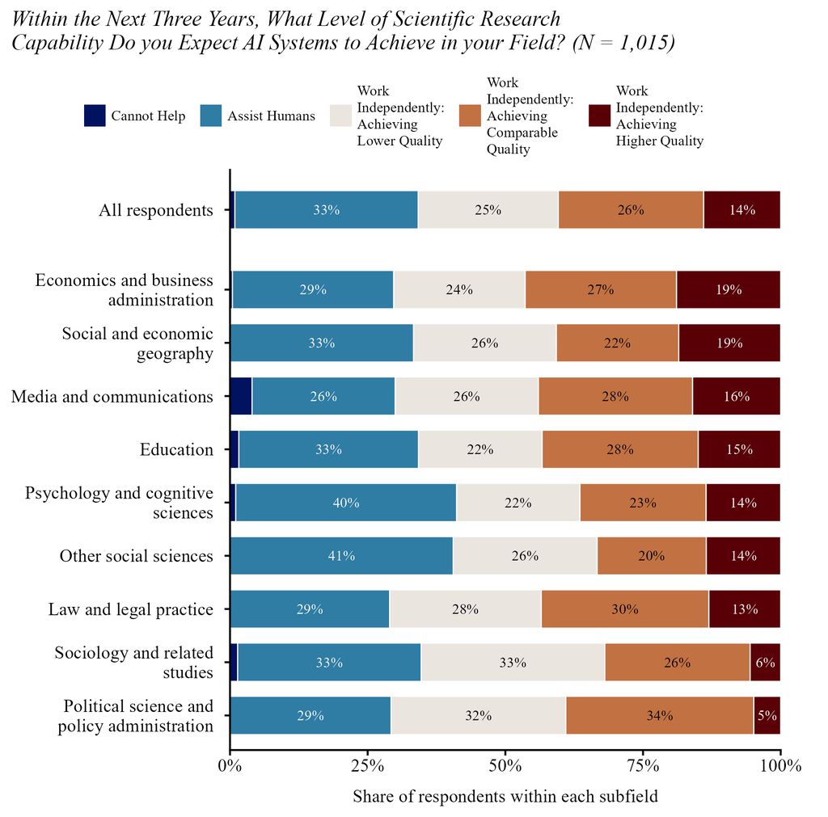

S5

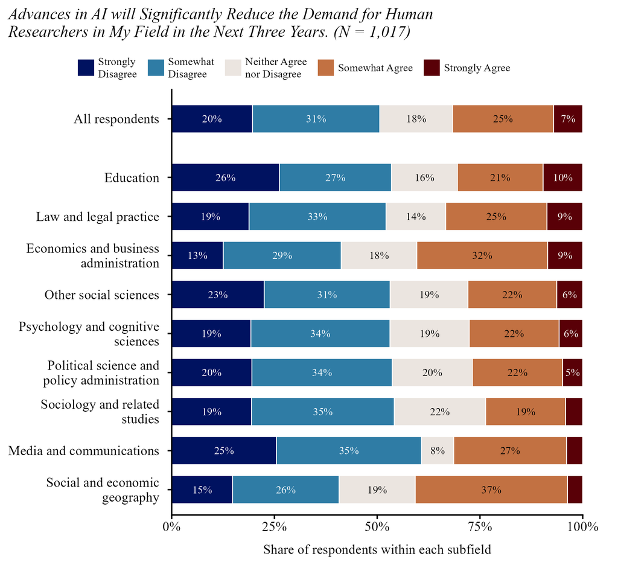

S6

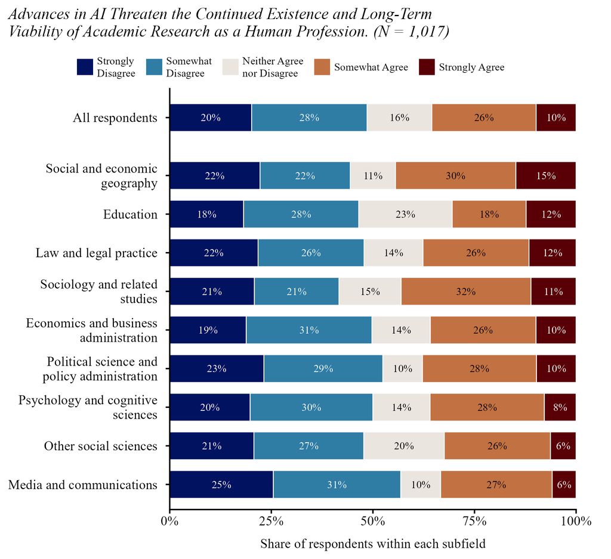

S7

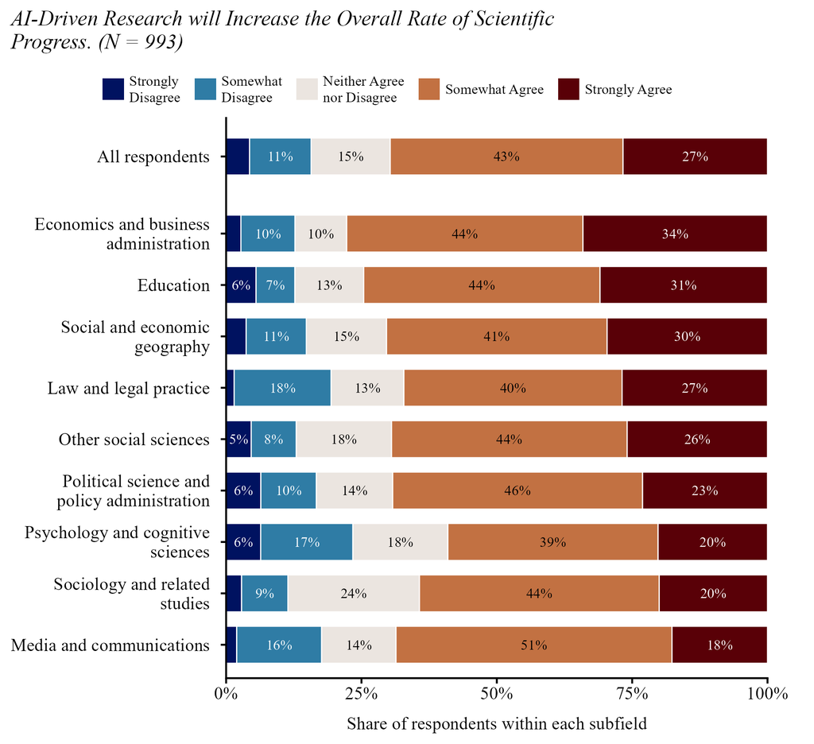

S8

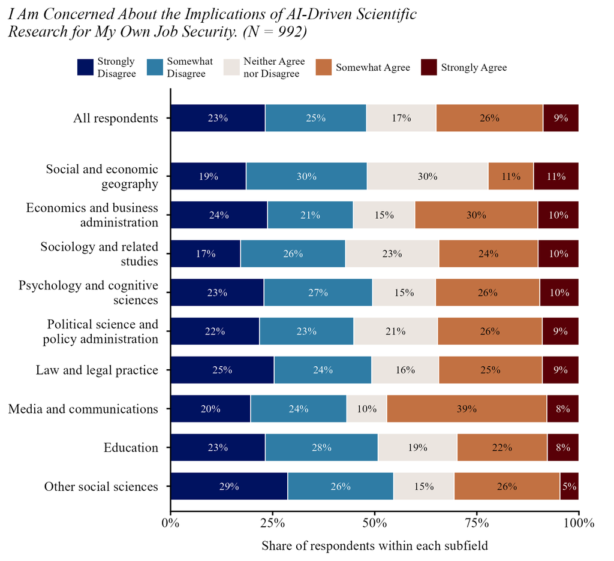

S9

## Disciplines within medical, health and life sciences

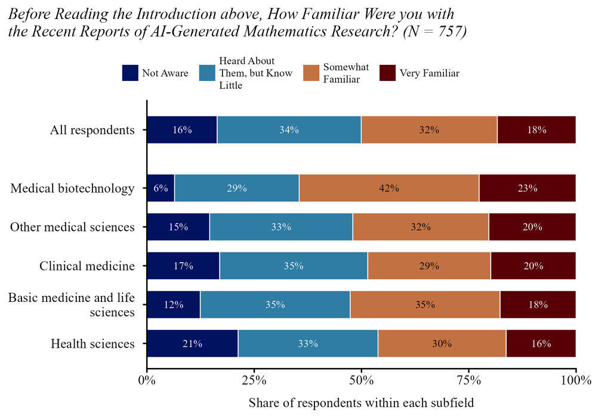

S10

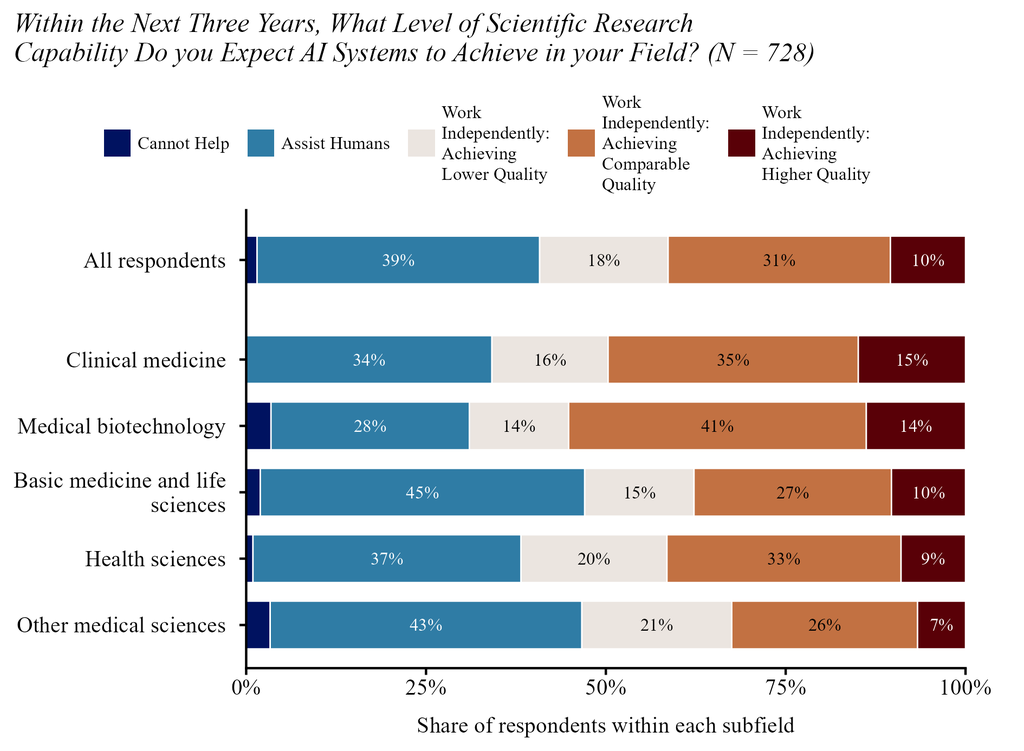

S11

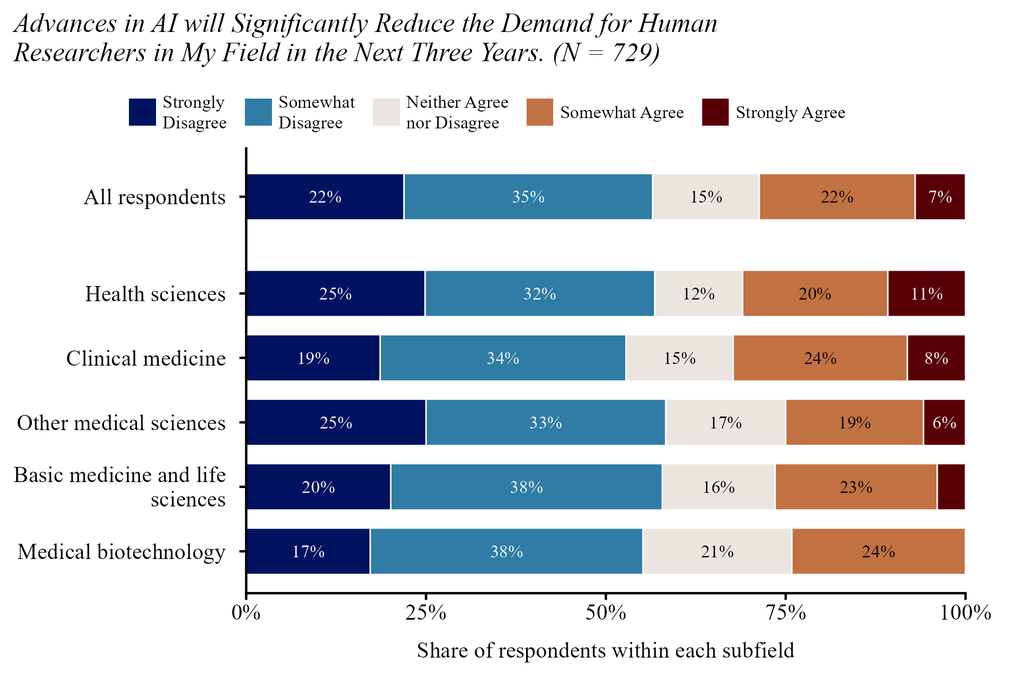

S12

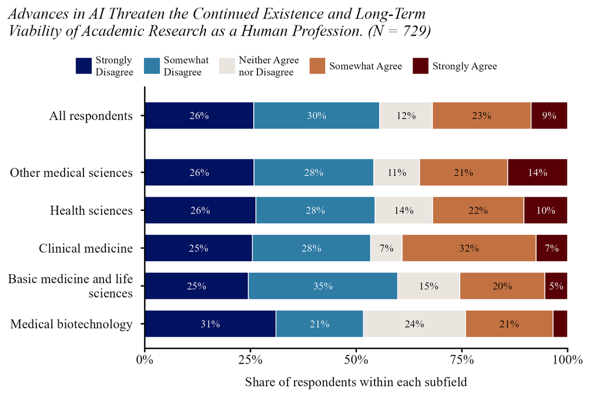

S13

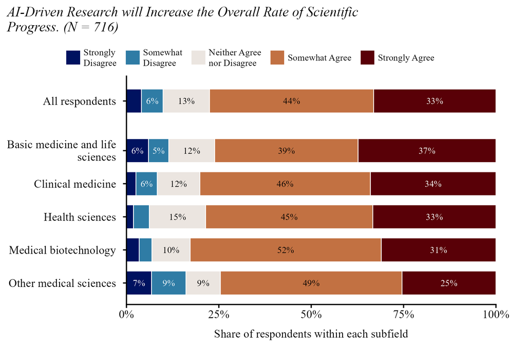

S14

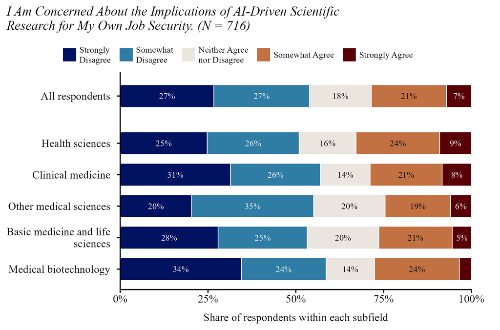

S15

## Disciplines within engineering and technology

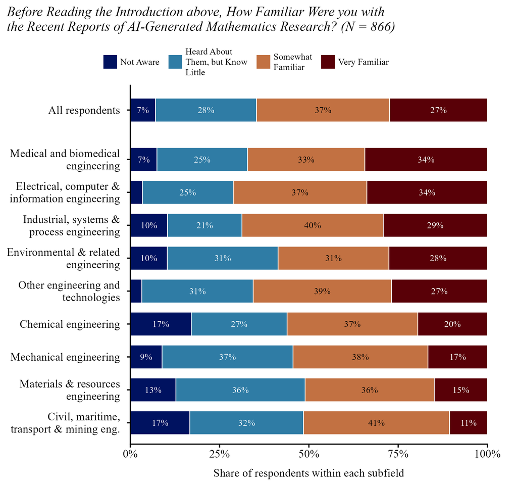

S16

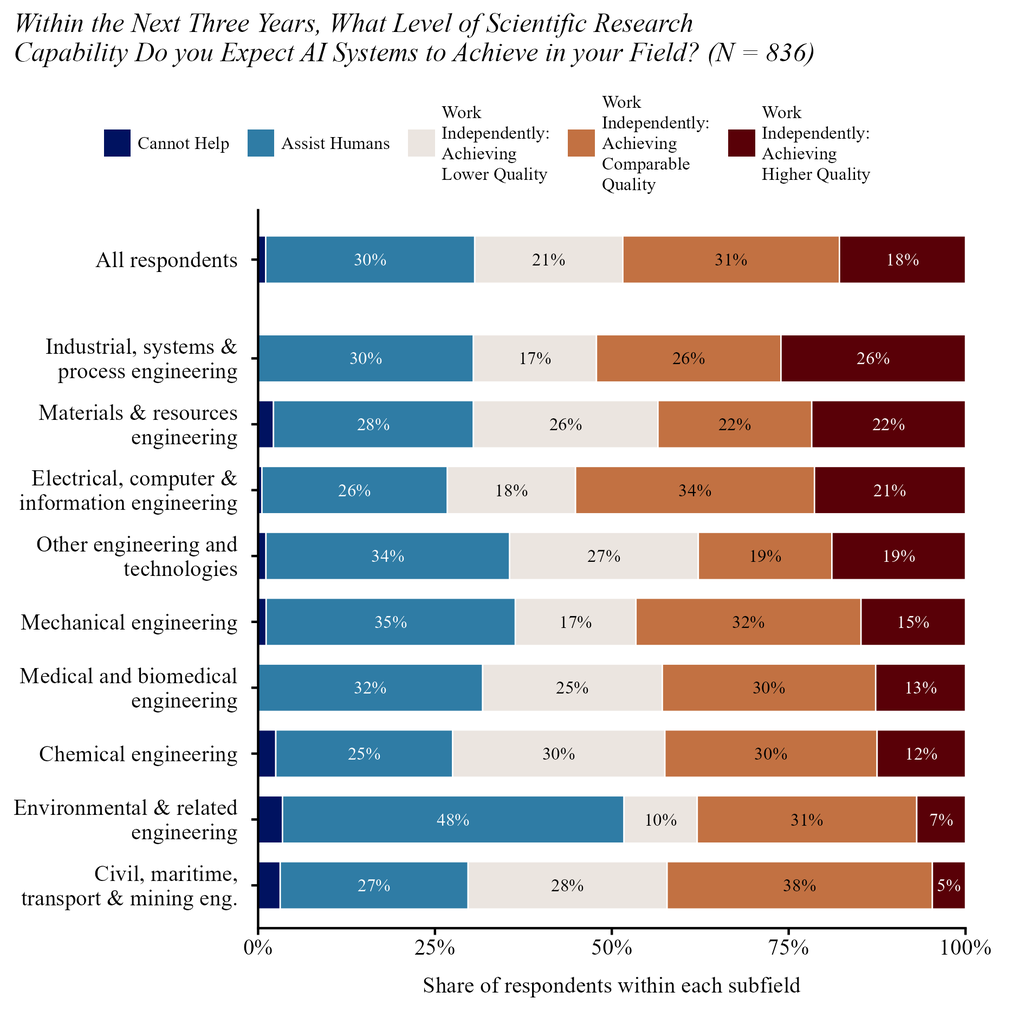

S17

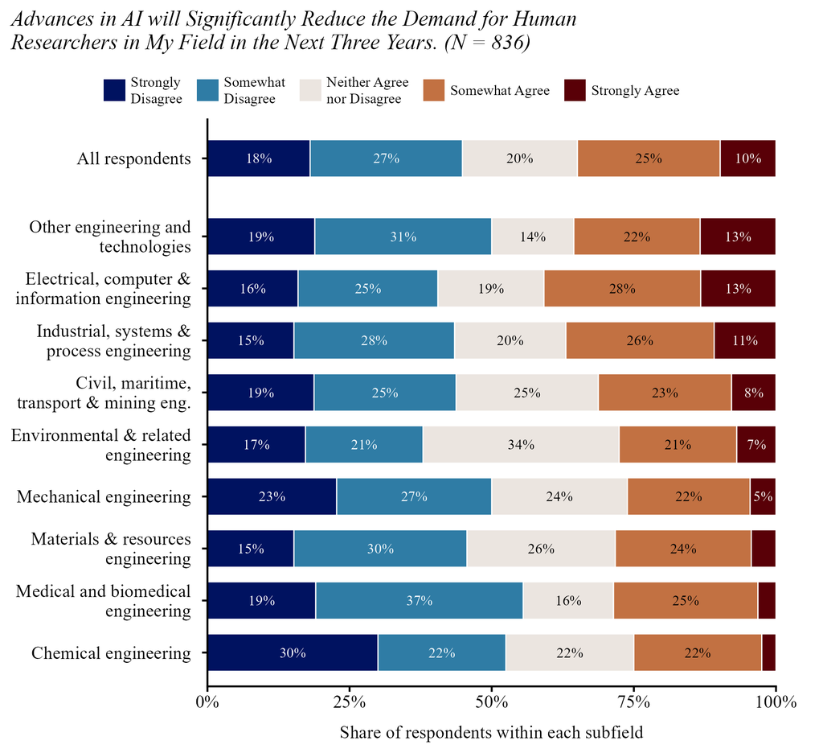

S18

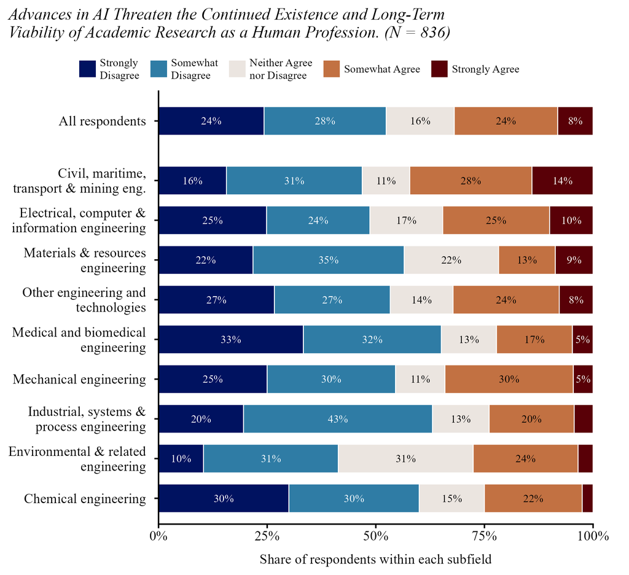

S19

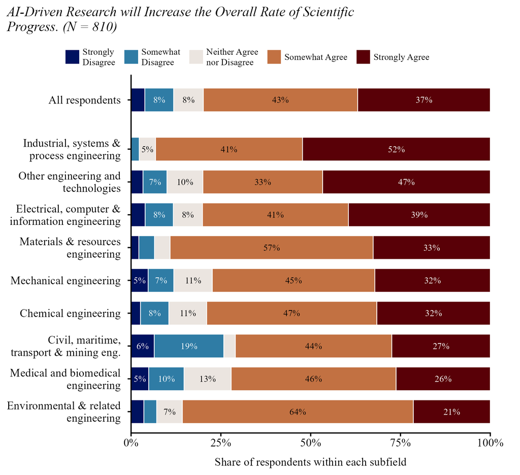

S20

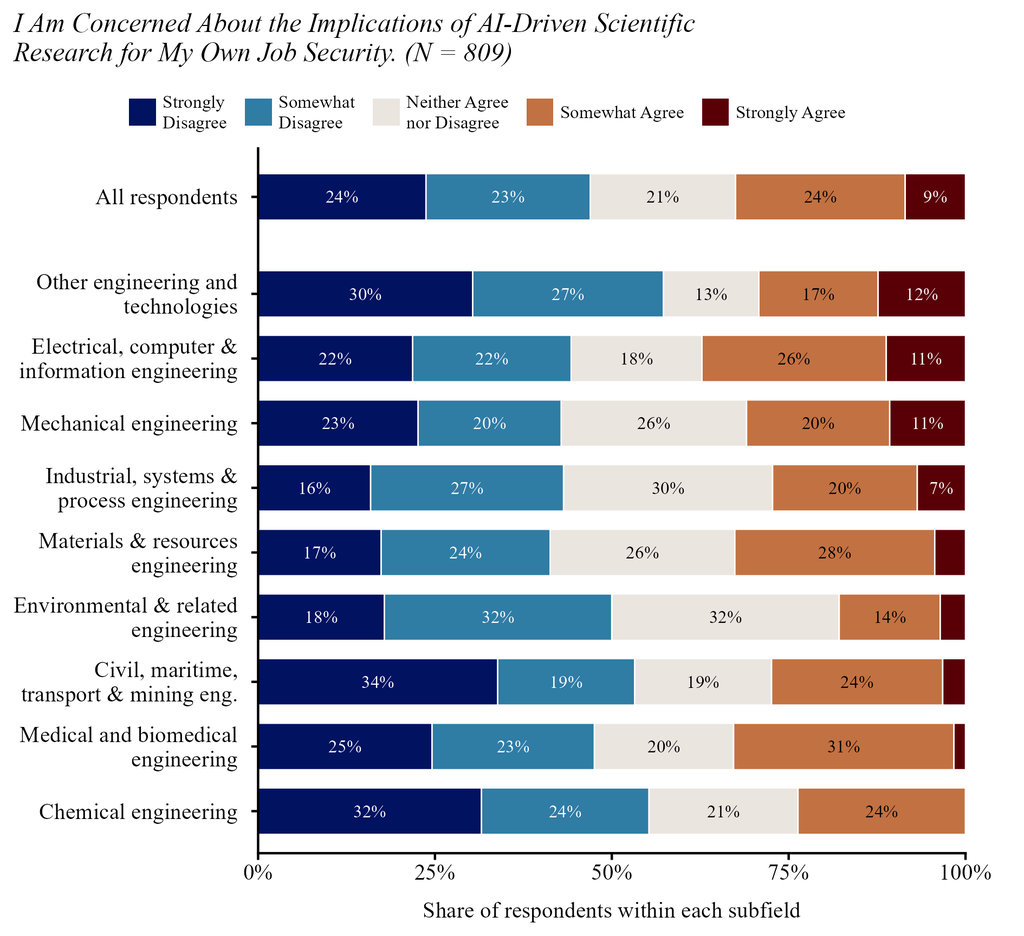

S21

## Disciplines within humanities and the arts

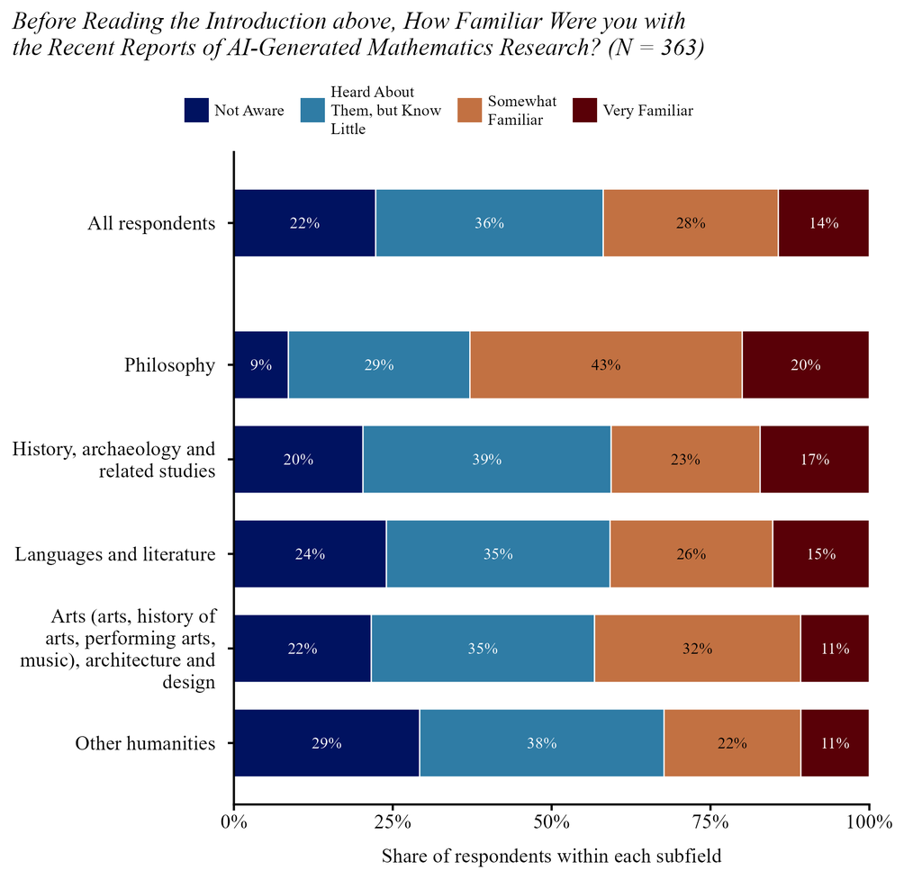

S22

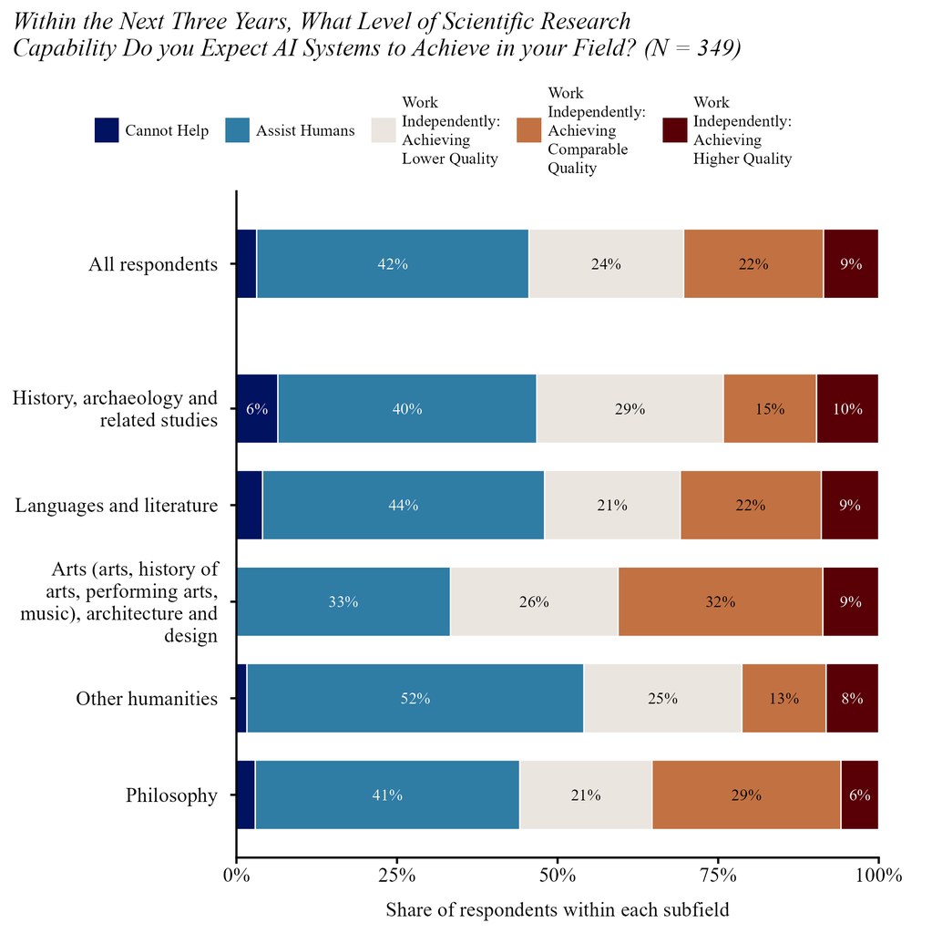

S23

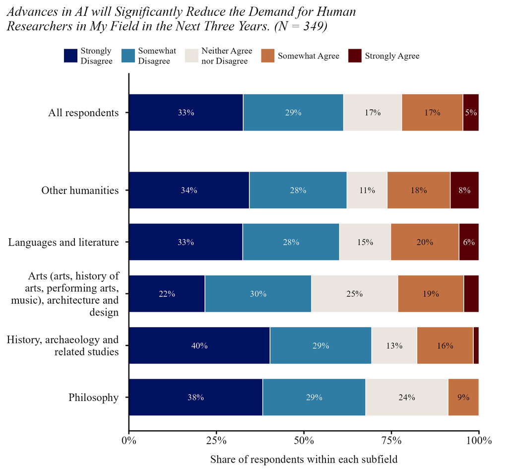

S24

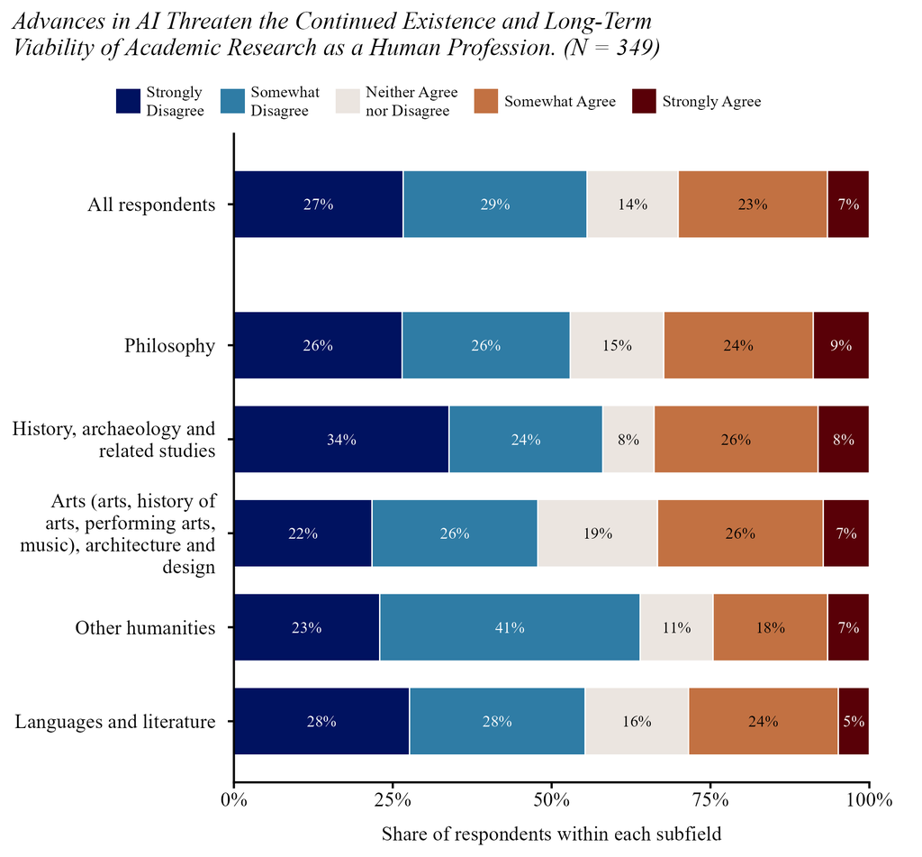

S25

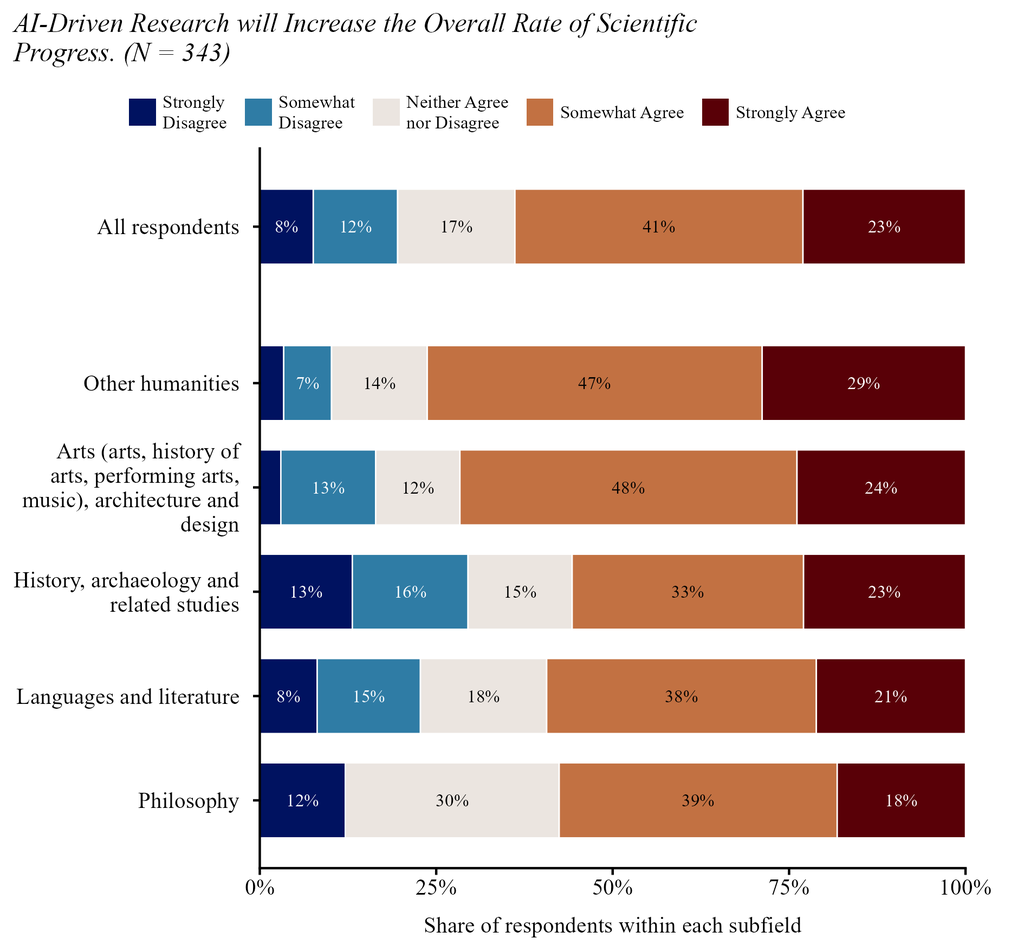

S26

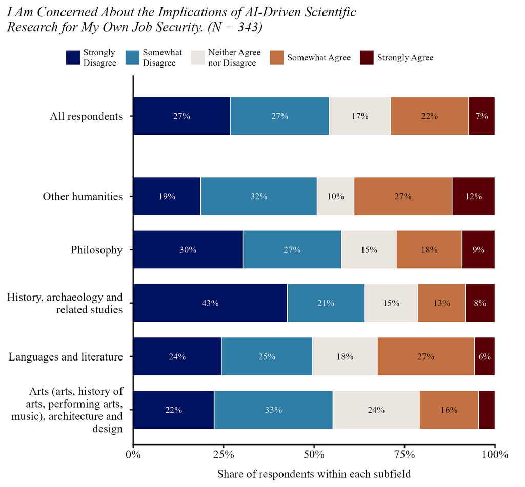

S27

## AI questions by career stage

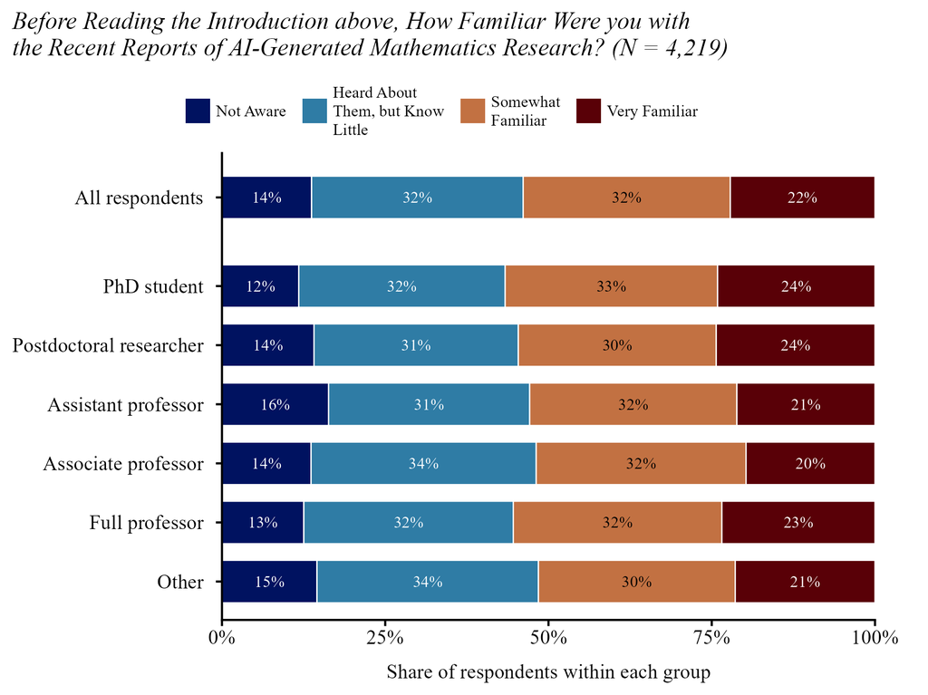

S28

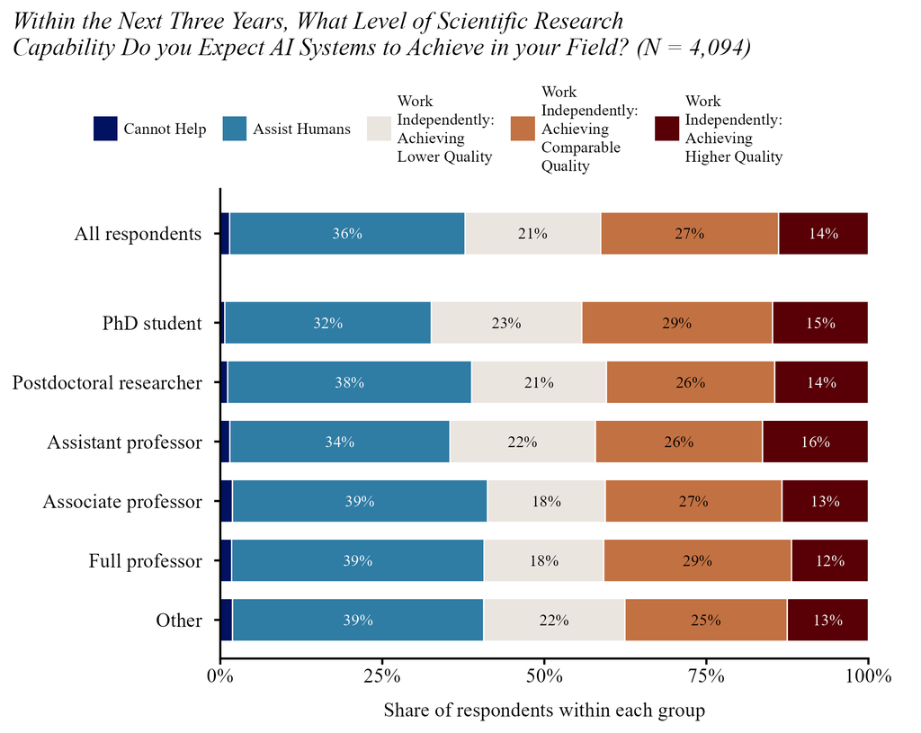

S29

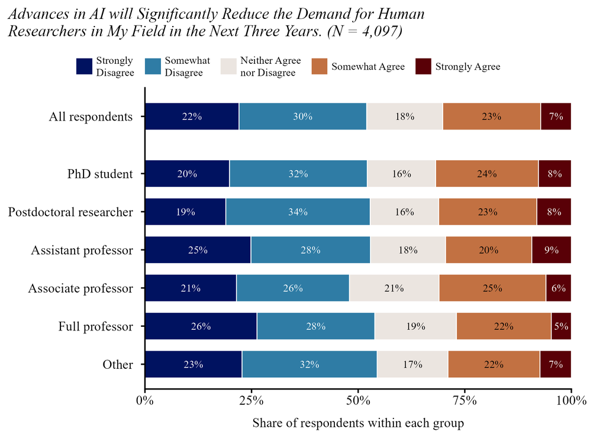

S30

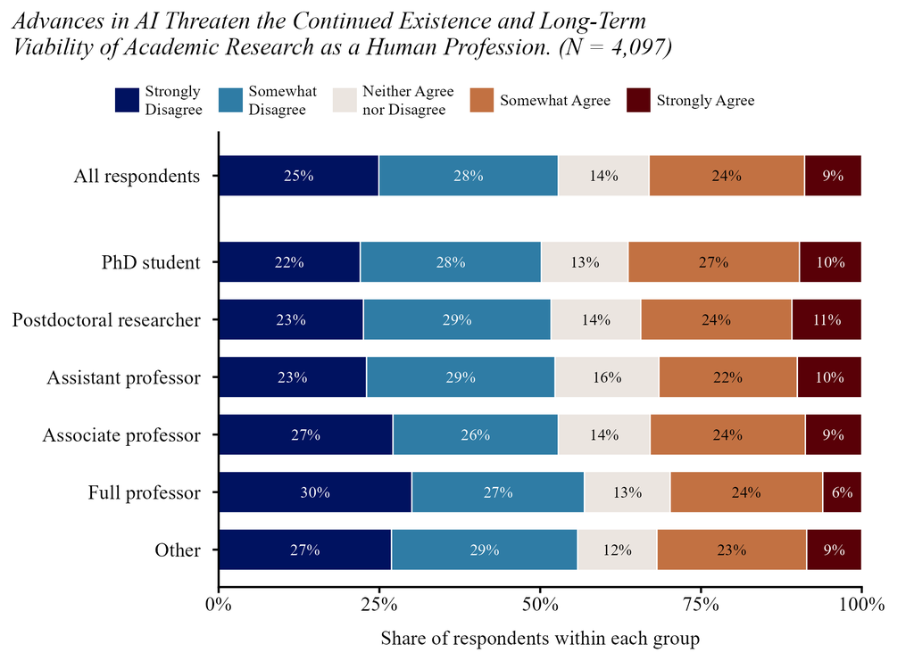

S31

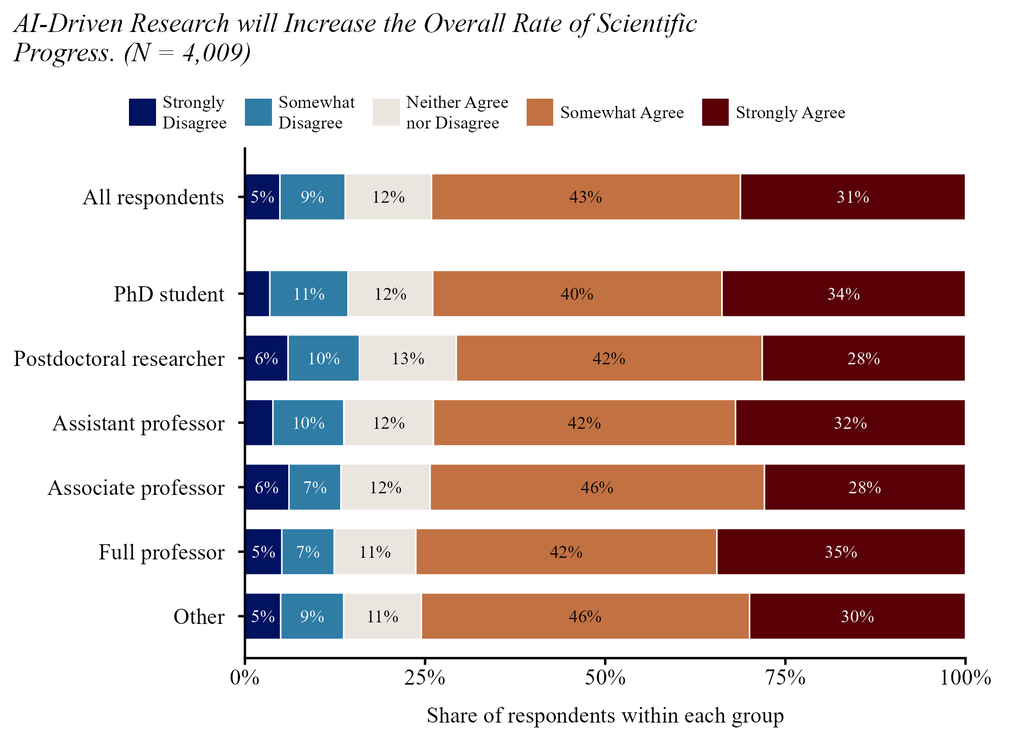

S32